# markov

Stochastic Systems

Markov Chains

Gloria del Valle Cano

```python
import numpy as np
import matplotlib.pyplot as plt
import seaborn as sns
from IPython.display import display, Math, Latex
```

Consider the following Markov Chain:

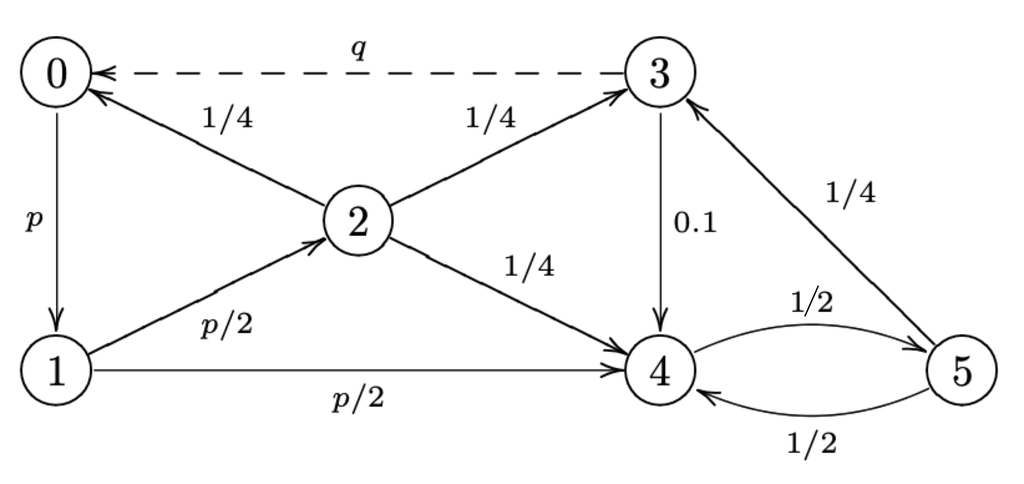

It is assumed that in each state there is an arrow to the same state that makes the sum of the output probabilities 1.

**i)** Determine the transition matrix of this chain.

```python
def t_matrix(p, q):
    """
    Returns transition probabilities for the markov model given p and q.
    Args:
        p (float): basic parameter for the transition.
        q (float): probability based on these values.
    """
                #        0      1       2       3       4       5
    return np.array([[  1-p,    p,    0.0,    0.0,    0.0,    0.0], # 0
                     [  0.0,  1-p,  p/2.0,    0.0,   p/2.0,   0.0], # 1
                     [1/4.0,  0.0,  1/4.0,   1/4.0,  1/4.0,   0.0], # 2
                     [    q,  0.0,    0.0, 1-q-0.1,    0.1,   0.0], # 3
                     [  0.0,  0.0,    0.0,     0.0,  1/2.0, 1/2.0], # 4
                     [  0.0,  0.0,    0.0,    1/4.0, 1/2.0, 1/4.0]  # 5
                     ])
```

**ii)** Simulate the operation of the chain and make an overall estimation of $h_o^2$ and $h_0^5$ for $q=0.1$ and $q=0$.

**iii)** Simulate the operation of the chain and make an overall estimation of $k_o^2$ and $k_4^2$ for $q=0.1$ and $q=0$.

Let's create a Markov class that computes the probabilities given by $P$ and simulates every step. This class also returns the hitting probability and the hitting time for reaching whichever states from a determined initial state, simulating $nc$ independent chains until $ns$ steps. Thus, it is obtained the mean hitting time, coded according to the following principles.

Let $(X_t)_{t≥0}$ be a Markov chain with transition matrix $P$. The hitting time of a subset $A$ is the random variable: $H^A: \Omega \to \{0,1,2,...\} \cup \{\infty\}$ given by $$ H^A(\omega) = \text{inf} \{t≥0: X_n(\omega) \in A\} $$ where we agree that the infimum of the empty set $0$ is $\infty$. The probability starting from $i$ that $(X_t)_{t≥0}$ ever hits A is then $$ h_i^A = P_i(H^A < \infty). $$ When $A$ is closed class, $h_i^A$ is called the *absorption probability*. The mean time taken for $(X_t)_{t≥0}$ to reach $A$ is given by $$ k_i^A = E_i(H^A) = \sum_{t<\infty} t P(H^A = t) + \infty P (H^A = \infty) $$

```python
class Markov:
    """
    Class that computes a Markov model using the transition
    matrix P starting from a specific state.
    """
    def __init__(self, P, m0):
        """
        Init function for Markov model.
        Args:
            P (np array): transition matrix.
            m0 (int): initial state.
        """
        self.P = P                 # P
        self.nst = len(self.P[0])  # number of states
        self.st = m0               # initial state

    def transition(self, st):
        """
        Determines a new state with the corresponding
        probabilities returning the value of the new state,
        generating a random event sampled from the uniform
        distribution.
        Args:
            st (int): actual state.
        """
        return np.where(np.random.uniform() < np.cumsum(self.P[st]))[0][0]

    def history(self, nst, m):
        """
        Returns the probability occupation of the previous state.
        Args:
            nst (int): number of states.
            m (int): probability of previous state.
        """
        return [m for i in range(nst)]

    def h__(self, nc, ns):
        """
        Computes the hitting probability to reach
        whichever states from initial state.
        Args:
            nc (int): number of chains.
            ns (int): number of states.
        """
        sts = np.zeros((nc, ns))
        sts[:, self.st] = 1
        hist = self.history(nc, self.st)
        for s in range(ns):
            for c in range(nc):
                st = self.transition(hist[c])
                sts[c, st] = 1
                hist[c] = st
        return sts

    def k__(self, nc, ns):
        """
        Computes the hitting time to reach
        whichever states from initial state.
        Args:
            nc (int): number of chains.
            ns (int): number of states.
        """
        sts = np.full((nc, ns), np.inf)
        sts[:, self.st] = 0
        hist = self.history(nc, self.st)
        for s in range(ns):
            for c in range(nc):
                st = self.transition(hist[c])
                if sts[c, st] == np.inf:
                    sts[c, st] = s
                hist[c] = st
        return sts
```

$P$ for $q=0.1$

```python
p = 0.3
q = 0.1
P = t_matrix(p, q)
```

We compute the hitting probabilities for $q=0.1$, and, for instance $nc=2000$ (number of chains) and $ns=2000$ (number of steps).

```python
states_h0 = Markov(P, 0).h__(2000, 2000)
states_k0 = Markov(P, 0).k__(2000, 2000)
states_k4 = Markov(P, 4).k__(2000, 2000)
```

Then, we obtain the average of the hitting probabilities and the mean hitting time for each case ($h_0^2$, $h_0^5$, $k_0^2$ and $k_4^2$).

```python
display(Latex(r'Hitting probabilities and hitting mean time for $q = {0}$'.format(q)))
display(Math(r'h_0^2 = {0}'.format(states_h0.mean(axis=0)[2])))
display(Math(r'h_0^5 = {0}'.format(states_h0.mean(axis=0)[5])))
display(Math(r'k_0^2 = {0}'.format(states_k0.mean(axis=0)[2])))
display(Math(r'k_4^2 = {0}'.format(states_k4.mean(axis=0)[2])))
```

Hitting probabilities and hitting mean time for $q = 0.1$

$\displaystyle h_0^2 = 1.0$

$\displaystyle h_0^5 = 1.0$

$\displaystyle k_0^2 = 44.6825$

$\displaystyle k_4^2 = 74.019$

$P$ for $q=0.0$

```python
p = 0.3
q = 0.0
P = t_matrix(p, q)
```

As before, let's compute the hitting probabilities for $q=0.0$, and again $nc=2000$ (number of chains) and $ns=2000$ (number of steps).

```python
states_h0 = Markov(P, 0).h__(2000, 2000)
states_k0 = Markov(P, 0).k__(2000, 2000)
states_k4 = Markov(P, 4).k__(2000, 2000)
```

Finally, we obtain the average of the hitting probabilities and the mean hitting time for each case ($h_0^2$, $h_0^5$, $k_0^2$ and $k_4^2$).

```python
display(Latex(r'Hitting probabilities and hitting mean time for $q = {0}$'.format(q)))
display(Math(r'h_0^2 = {0}'.format(states_h0.mean(axis=0)[2])))
display(Math(r'h_0^5 = {0}'.format(states_h0.mean(axis=0)[5])))
display(Math(r'k_0^2 = {0}'.format(states_k0.mean(axis=0)[2])))
display(Math(r'k_4^2 = {0}'.format(states_k4.mean(axis=0)[2])))
```

Hitting probabilities and hitting mean time for $q = 0.0$

$\displaystyle h_0^2 = 0.501$

$\displaystyle h_0^5 = 1.0$

$\displaystyle k_0^2 = inf$

$\displaystyle k_4^2 = inf$

**iv)** Use the appropriate system of linear equations to determine the theoretical values corresponding to the estimated quantities and compare with the values determined by simulation (caution: if a quantity $k$ is $\infty$ the simulation clearly cannot give its real value... discuss this case).

- $q=0.1$.
  - $h_0^2$: $$\left\{ \begin{array}\\ h_0 = (1-p)h_0 + ph_1 \\ h_1 = (1-p)h_1 + \frac p 2 h_2 + \frac p 2 h_4 \\ h_2 = 1 \\ h_3 = qh_0 + (0.9-q)h_3 + 0.1h_4 \\ h_4 = \frac 1 2 h_4 + \frac 1 2 h_5 \\ h_5 = \frac 1 4 h_3 + \frac 1 2 h_4 + \frac 1 4 h_5 \end{array}\right.\longrightarrow h_0^2=1 $$
  - $h_0^5$: $$\left\{ \begin{array}\\ h_0 = (1-p)h_0 + ph_1 \\ h_1 = (1-p)h_1 + \frac p 2 h_2 + \frac p 2 h_4 \\ h_2 = \frac 1 4 h_0 + \frac 1 4 h_2 + \frac 1 4 h_3 + \frac 1 4 h_4 \\ h_3 = qh_0 + (0.9-q)h_3 + 0.1h_4 \\ h_4 = \frac 1 2 h_4 + \frac 1 2 h_5 \\ h_5 = 1 \end{array}\right. \longrightarrow h_0^5=1 $$
  - $k_0^2$ and $k_4^2$ (*): $$\left\{ \begin{array}\\ k_0 = 1 + (1-p)k_0 + pk_1 \\ k_1 = 1 + (1-p)k_1 + \frac 1 2 k_2 + \frac 1 2 k_4 \\ k_2 = 0 \\ k_3 = 1 + qk_0 + (0.9-q)k_3 + 0.1k_4 \\ k_4 = 1 + \frac 1 2 k_4 + \frac 1 2 k_5 \\ k_5 = 1 + \frac 1 4 k_3 + \frac 1 2 k_4 + \frac 1 4 k_5 \end{array}\right.\longrightarrow \left\{\begin{array}\\k_0^2=43.33\\k_4^2=73.33 \end{array}\right. $$

(*) Last case can be easily resolved with *numpy*, because it's a determined system with unique solution:

```python
q = 0.1
 #        0       1       2        3        4        5
M_2 = [[1-p-1,     p,    0.0,    0.0,    0.0,       0.0], # 0
      [  0.0,  1-p-1,  p/2.0,    0.0,   p/2.0,      0.0], # 1
      [  0.0,    0.0,      1,    0.0,     0.0,      0.0], # 2
      [    q,    0.0,    0.0, 0.9-q-1,    0.1,      0.0], # 3
      [  0.0,    0.0,    0.0,    0.0,   1/2.0-1,  1/2.0], # 4
      [  0.0,    0.0,    0.0,   1/4.0,  1/2.0,  1/4.0-1]] # 5

display(Latex(r"For $q=0.1$:"))
display(Math(r"k_0^2 = {0}".format(np.linalg.solve(M_2, -np.array([1,1,0,1,1,1]))[0])))
display(Math(r"k_4^2 = {0}".format(np.linalg.solve(M_2, -np.array([1,1,0,1,1,1]))[4])))
```

For $q=0.1$:

$\displaystyle k_0^2 = 43.333333333333336$

$\displaystyle k_4^2 = 73.33333333333337$

These results match the simulation values.

- $q=0$. (So $\{3,4,5\}$ is a closed class).
  - $h_0^2$: $$\left\{ \begin{array}\\ h_0 = (1-p)h_0 + ph_1 \\ h_1 = (1-p)h_1 + \frac p 2 h_2 \\ h_2 = 1 \\ h_3=h_4=h_5=0 \end{array}\right.\longrightarrow h_0^2=\frac 1 2 $$
  - $h_0^5$: $$\left\{ \begin{array}\\ h_0 = (1-p)h_0 + ph_1 \\ h_1 = (1-p)h_1 + \frac p 2 h_2 + \frac p 2h_4 \\ h_2 = \frac 1 4 h_0 + \frac 1 4 h_2 + \frac 1 4 h_3 + \frac 1 4 h_4 \\ h_3 = 0.9h_3 + 0.1h_4 \\ h_4 = \frac 1 4 h_4 + \frac 1 2 h_5 \\ h_5 = 1 \end{array}\right.\longrightarrow h_0^5=1 $$
  - $k_0^2$ and $k_4^2$ (indeterminate system): $$\left\{ \begin{array}\\ k_0 = 1 + (1-p)h_0 + ph_1 \\ k_1 = 1 + (1-p)h_1 + \frac p 2 h_2 + \frac p 2 h_4 \\ k_2 = 0 \\ k_3 = k_4 = k_5 = \infty \end{array}\right.\longrightarrow \left\{\begin{array}\\k_0^2=\infty\\k_4^2=\infty \end{array}\right. $$

**v)** For $q = 0.1$, plot $g(t) = P[H_0^{\{4\}} = t]$

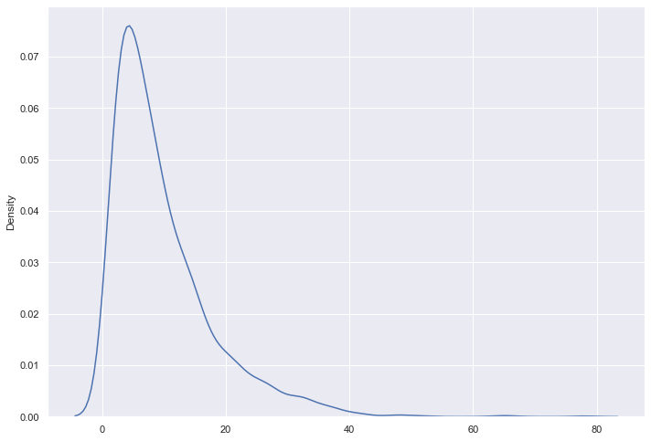

```python
# Initial values
p = 0.3
q = 0.1
P = t_matrix(p, q)
# Create Markov chain from the state 0 and return probabilities
states_H0 = Markov(P, 0).k__(2000, 2000)
# Plot kde (density estimation) for k probability for state 4
sns.set(rc={'figure.figsize':(11.7, 8.27)})
sns.kdeplot(states_H0[:,4])
plt.show()
```

We see that in $t=0$ we are in state 0 so our probability is 0. When we get the state 4 for first time the probability increases until it reaches the maximum and then our probability to reach again the state 4 decreases.

**vi)** Affirming $H_0^{\{4\}} < H_0^{\{5\}}$. Is it true/false? Why? (Choose the appropriate option).

It's true because it's necessary to get first the state 4 to get the state 5. Therefore, the time it takes to reach state 5 from state 4 will always be at least 1 time unit after. This is corroborated by:

```python
(states_H0[:,4] < states_H0[:,5]).all()
```

```
True
```

```python
from IPython.core.display import HTML
HTML("""
<style>
    .qst {
        background-color: #E2EAF5;
        padding:25px;
        border-radius: 5px;
        border: solid 2px #5D8AA8;
    }

    .qst:before {
        font-weight: bold;
        display: block;
        margin: 0px 10px 10px 10px;
    }

    .qst2 {
        background-color: #F2ECD9;
        padding:25px;
        border-radius: 5px;
        border: solid 2px #E7CE78;
    }

    .qst2:before {
        font-weight: bold;
        display: block;
        margin: 5px 10px 10px 10px;
    }
    </style>
""")
```